# IRT-NLME_Tutorial

Krina Mehta

2025-11-24

# Set up

We first read libraries and setup data and models directories.

```r
# gc()
rm(list=ls())

library(tidyverse)
library(piraid)
library(ggh4x)
library(xpose)

data_dir <- "../data"
nonmem_dir <- "../models"
```

# Data

Let’s first review our data. Some links to the study details from which these data were taken from are as follows. Note that the provided dataset includes only control arm data.

- https://clinicaltrials.gov/study/NCT00081796?tab=table
- https://www.sanofi.com/assets/dotcom/content-app/clinical-studies/pharma/Letter-L/EFC6089_summary.pdf

We will first do some simple data management to get the data ready for the analyses. Note that NONMEM does not accept non-numeric data columns; thus, we need to convert all covariates data columns into numeric format.

```r
# load data and perform some data wrangling (add grouping, add numeric columns for categorical variables)
dat = read.csv(file.path(data_dir, "EQLQ_Clean_2004_23JUN2025.csv"),
                 stringsAsFactors = F, na.string=c(".","NA","")) %>%
      select(UID, ID, ITEM=FLAG, TIME, TAFR, DV, everything())  %>%
      mutate(STUDYN = as.numeric(as.factor(NCT)),
             SEXN = as.numeric(as.factor(SEX)),
             ECOG = ifelse(ECOG=="0", 0, ifelse(ECOG=="1", 1, NA)),
             MENOSN = as.numeric(as.factor(MENOS)),
             CHEMO = ifelse(CHEMO=="Y", 1, ifelse(CHEMO=="N", 0, NA)),
             SURGERY = ifelse(SURGERY=="Y", 1, ifelse(SURGERY=="N", 0, NA)),
             RADIO = ifelse(RADIO=="Y", 1, ifelse(RADIO=="N", 0, NA)),
             ERS = ifelse(ERS=="Positive",1, ifelse(ERS=="Negative", 0, NA)),
             PGRS = ifelse(PGRS=="Positive",1, ifelse(PGRS=="Negative", 0, NA)),
             MHDEPRESSION = ifelse(MHDEPRESSION=="Y", 1,
                                   ifelse(MHDEPRESSION=="N", 0, NA)),
             MDANXIETY =  ifelse(MDANXIETY=="Y", 1, ifelse(MDANXIETY=="N", 0, NA)),
             ITMGRP = ifelse(ITEM %in% 1:5, "Physical Function",
                       ifelse(ITEM %in% 6:7, "Role Function",
                       ifelse(ITEM %in% c(20,25), "Cognitive Function",
                       ifelse(ITEM %in% 21:24, "Emotional Function",
                       ifelse(ITEM %in% c(26,27), "Social Function",
                       ifelse(ITEM %in% 8:19, "Symptoms",
                       ifelse(ITEM %in% 28, "Financial Difficulties",
                       ifelse(ITEM %in% 29:30, "Global Health Status", NA)))))))),
             ITMGRPN = as.numeric(as.factor(ITMGRP)))
```

## Explore data

The purpose of the first set of data explorations is to plan data cleaning steps.

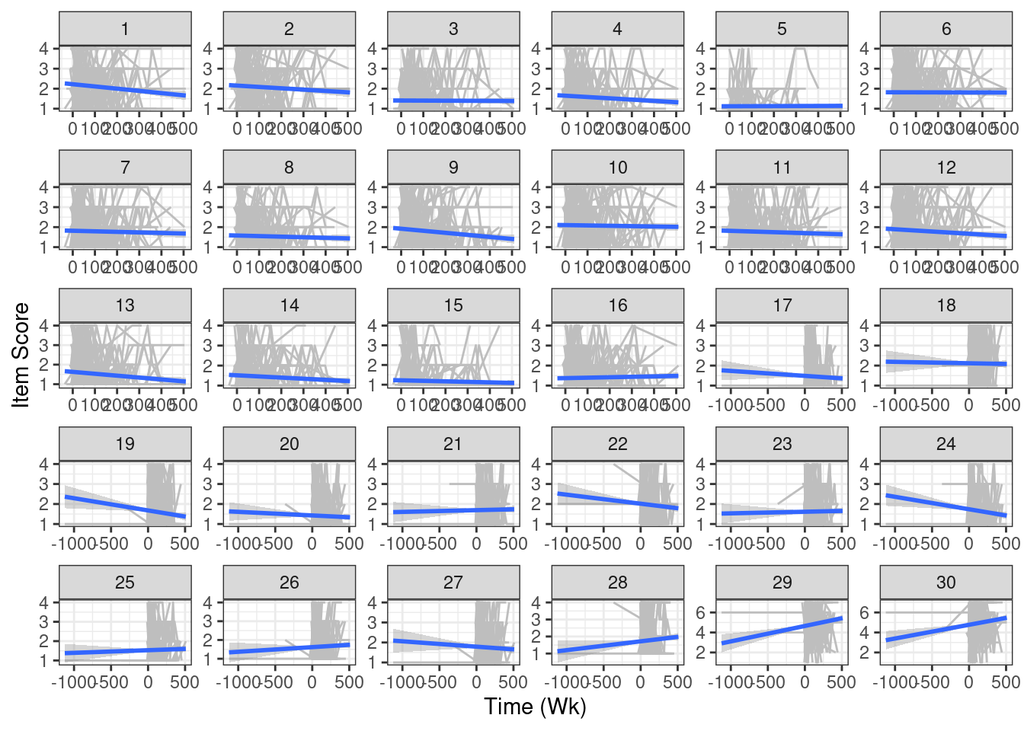

```r
# Review all items all timepoints
print(ggplot(dat,aes(x=TIME, y=DV)) +
  geom_line(aes(group=ID), color="grey", size=0.5) +
  facet_wrap(~ITEM, scales="free") +
  geom_smooth(method="lm") + ylab("Item Score") + xlab("Time (Wk)") +
  theme_bw())
```

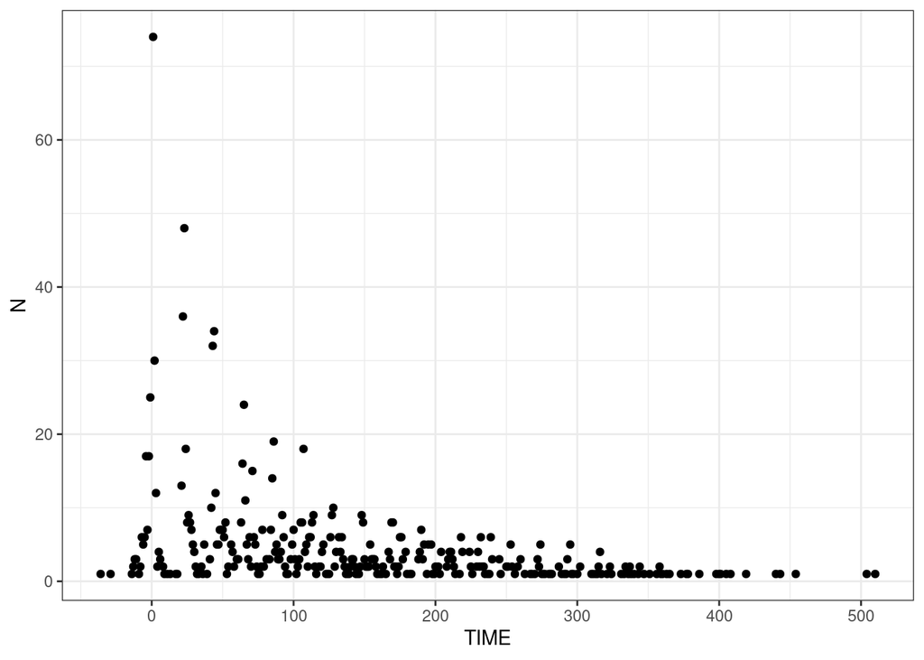

```r
# Check data points per time
tabdat <- dat %>%
    group_by(TIME, ITEM) %>%
    summarize(N= n()) %>%
    ungroup() %>%
    arrange(desc(N), TIME, ITEM)

# Check data points per time (just filtering one item to check sample size over time)
tabdat <- dat %>%
    filter(ITEM==1) %>%
    group_by(TIME, ITEM) %>%
    summarize(N= n()) %>%
    ungroup() %>%
    arrange(desc(N), TIME, ITEM)

# Plot sample size per time
print(ggplot(tabdat, aes(x=TIME, y=N)) +
  geom_point() +
  theme_bw())
```

## Data cleaning and wrangling

A key assumption in IRT is unidimensionality—whether all items measure the same underlying latent trait, denoted by $\Psi$. In the EORTC QLQ-C30 dataset, items 1-27 capture symptom burden or physical/emotional functional impairment, with higher scores indicating worse health. Items on financial difficulty (28) and global health status (29–30) differ conceptually and, in the case of global health, the scoring direction is reverse. Thus, for the purpose of this tutorial, we ignore items 28, 29, and 30.

Also, we convert time from days to weeks.

```r
# Apply above discussed filters and arrange datapoints

dat <- dat %>%
  filter(ITEM < 28, TIME>=-2) %>% # Very negative time points (pre-screening removed)
  mutate(WEEK = floor(TIME/7)) %>%
  group_by(ID, WEEK, ITEM) %>%
  slice(1) %>% ungroup() %>%
  mutate(OID=ID, ID =as.numeric(factor(OID)), DAY=TIME) %>%
  select(ID, DAY, TIME=WEEK, ITEM, everything(), -TIME) %>%
  arrange(ID, TIME, ITEM)

## Remove time points where items are missing per ID and TIME
# rmvdat <- dat %>%
#   group_by(ID, TIME) %>%
#   summarize(NITEM = n()) %>%
#   ungroup() %>%
#   filter(NITEM < 25)

# Filtered data
# datN <- anti_join(dat, rmvdat, by = c("ID", "TIME"))

# Check removed data
#knitr::kable(rmvdat, caption="List of ignored/removed data points")
# length(unique(rmvdat$ID))

# Check N IDs
# length(unique(datN$ID))

# Write full data version
write.csv(dat,
          file.path(data_dir, "Analysis_Data_Full.csv"),
          row.names = F, na=".", quote=F)

## filter columns only for nonmem
datnm1 <- dat %>% select(ID, TIME, DAY, ITEM, DV)
datnm2 <- dat %>% select(ID, TIME, DAY, ITEM, DV, AGE, MENOSN, LESION1, ECOG,
                          CHEMO, SURGERY, RADIO, ERS, PGRS, MHDEPRES=MHDEPRESSION,
                          MDANXIET=MDANXIETY, WEIGHT, PFS, ITMGRPN)

## Write only nm data version
write.csv(datnm1,
          file.path(data_dir, "Analysis_Data_nm.csv"),
          row.names = F, na=".", quote=F)

## Write only nm data version
write.csv(datnm2,
          file.path(data_dir, "Analysis_Data_nm_wCov.csv"),
          row.names = F, na=".", quote=F)
```

## Explore clean data

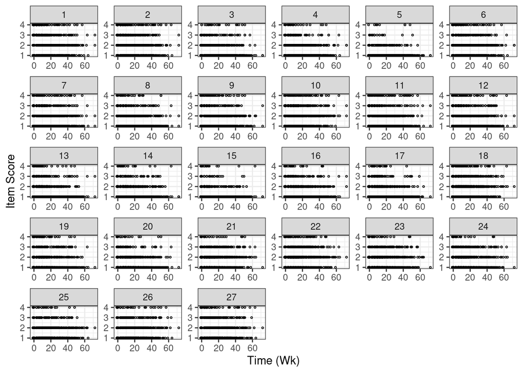

```r
# Plot clean data that will be used for IRT step
ggplot(dat,aes(x=TIME, y=DV)) +
  geom_point(size=0.5, shape=1) +
  facet_wrap(~ITEM, scales="free") +
  ylab("Item Score") + xlab("Time (Wk)") +
  theme_bw() + theme(legend.position="none")
```

# IRT Modeling

We will use piraid library (Check https://github.com/UUPharmacometrics/piraid for more details).

Also, review the following references to learn more about pharmacometrics IRT modeling.

- https://pmc.ncbi.nlm.nih.gov/articles/PMC5915608/
- https://www.page-meeting.org/?abstract=8869
- https://pubmed.ncbi.nlm.nih.gov/28247193/

## Load scale

```r
# Infer scale using piraid function data
# scale <- create_scale_from_df(dat)
# save_scale(scale, "EORTC_QOLE30_auto.yaml")
# scale

# load scale with piraid
scale = load_scale("EORTC_QOLE27.yaml")

# this scale was manually prepared

# Check data
check_data(dat, scale)
```

```
## The dataset is in agreement with the scale definition
```

## Create and run item-response model (Base Model)

Once our data and YAML scale files are ready, we are now ready to create our base model code and also get initial estimates using Piraid functions.

For item, longitudinal item characteristic curves are fitted using a two-parameter logistic (2PL) model. The probability that the response $y_{ij}$ for subject $i$ on item $j$ is greater than or equal to a score $s$ is given by:

$$P(y\_{ij} \geq s) = \frac{1}{1 +
\exp\big(a_j \cdot (b_{j,s} - \psi_i)\big)}$$

where $\Psi_i$ represents the latent ability (or disease burden) of subject $i$, $j$ denotes the item, $a_j$ is the discrimination parameter for item $j$, and $b_{j,s}$ is the difficulty parameter for the $s^{th}$ step of the item, with $b_{j,s} \leq b_{j,s+1}$. The relative scale for $\psi$ is defined by setting the baseline population reference $\psi_{\text{base}}$ to have mean 0 and variance 1. The individual longitudinal score $\psi_i$ is estimated as a patient/disease-related parameter. The probability of an exact score $s$ is computed as:

$$P(y\_{ij} = s) = P(y\_{ij} \geq s) -
P(y\_{ij} \geq s+1)$$

```r
# Model file creation
model = irt_model(scale) %>%
  set_dataset(file.path(data_dir, "Analysis_Data_nm.csv"), use_path = TRUE)

## Initial estimates for the item parameters
item_prms = estimate_item_parameters(model, "all-baseref")
model = model %>% update_parameters(., item_prms)

# The 'all-baseref' strategy also uses all available data but defines the population at baseline as a reference (mean 0, variance 1). Observations from later timepoints are treated as separate subjects.

### Only need to save the first time this is run (else it will be overwritten)
## Save model as nonmem file
# save_model_code(model, file.path(nonmem_dir, "run1.mod"))
```

Run nonmem model using PsN: execute run1.mod -clean=5

## Review item parameters

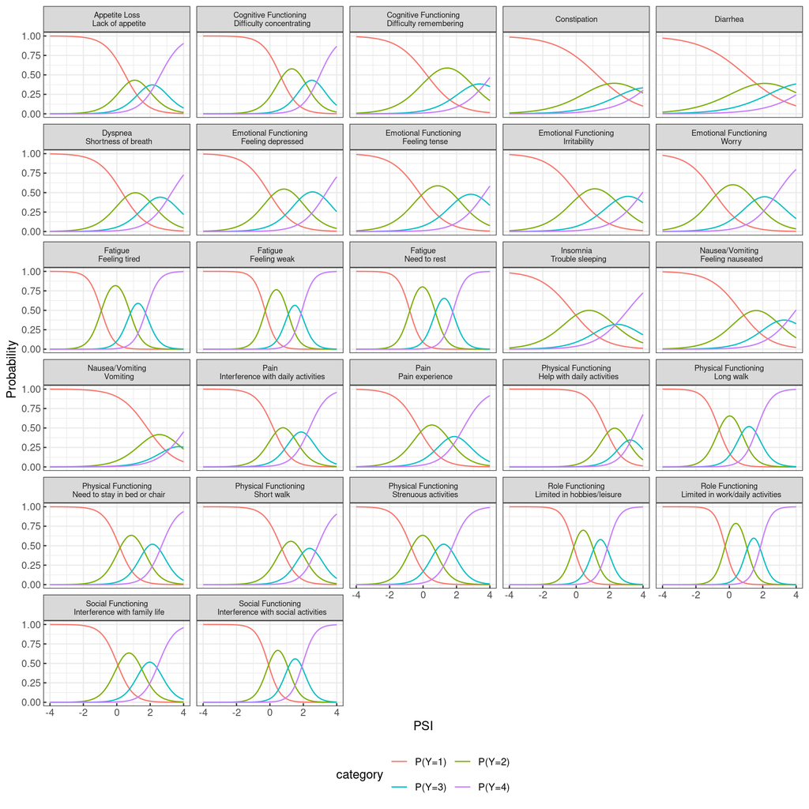

```r
# Read estimated parameters from run1
item_prms <- read_item_parameters_from_nmtab(model,
                                             file.path(nonmem_dir, "irt_tab1"))

# Plot ICCs from run1
P1 <- plot_iccs(model)
P1$data$item  <- gsub(":", "\n ", P1$data$item)
P1 + ggh4x::facet_wrap2(~item, ncol=5) +
  theme_bw() +
  theme(strip.text.x = element_text(size = 7),
        axis.ticks.length = unit(-2.75, "pt"),
        axis.text.x.bottom = element_text(),
        axis.text.y.left = element_text(),
        legend.position = "bottom", legend.box="horizontal") +
  guides(color = guide_legend(nrow = 2, byrow = TRUE))
```

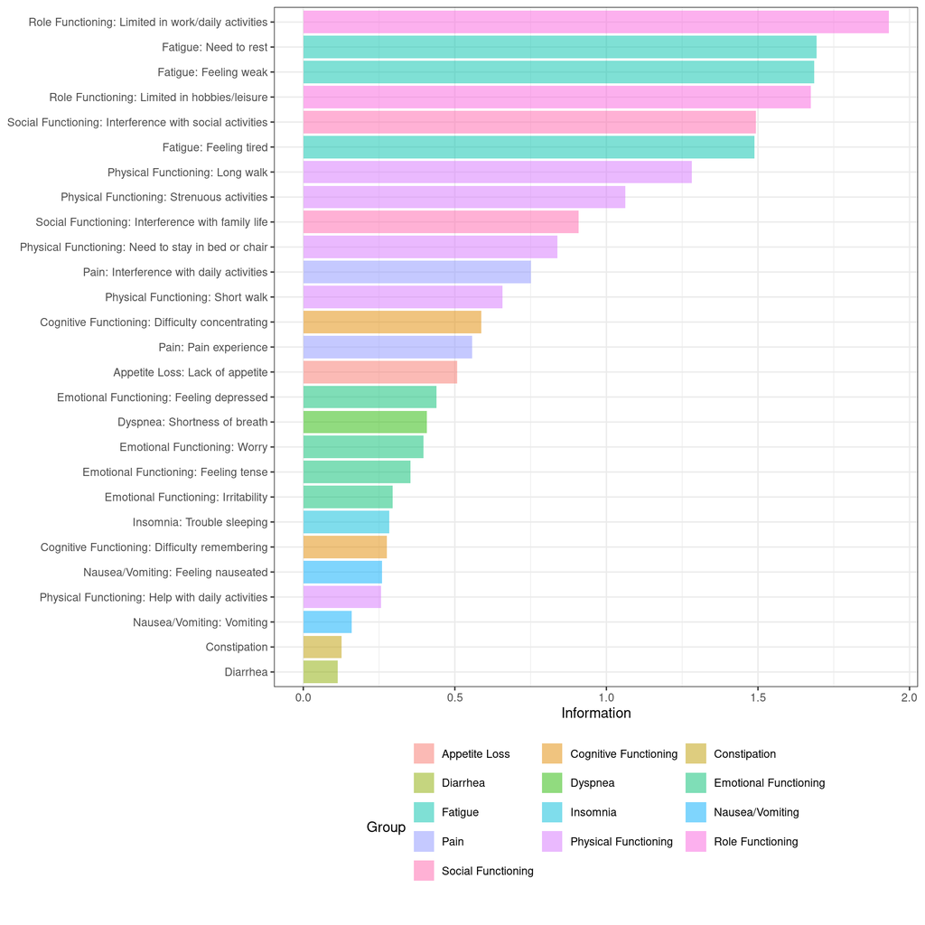

```r
#Plot Information Content from ICCs from run1
iteminfo <- calculate_population_item_information(model, mean=0, var=1) %>%
      mutate(item = fct_reorder(item, information)) %>%
      mutate(Group = sub(":.*", "", item))

P2 <- ggplot(data=iteminfo, aes(x=item, y=information, fill=Group)) +
       geom_col(alpha=0.5) +
       xlab(NULL) +
       ylab("Information") +
       coord_flip() +
       theme_bw() +
       theme(legend.position = "bottom") +
       guides(fill = guide_legend(nrow = 6, byrow = TRUE))
P2
```

# NLME Modeling of PSI

```r
# To create a new model (run2), first fix all IRT parameters to run1 estimates
model = model %>% update_parameters(., item_prms) %>% fix_all_item_parameters(.)

### Save updated model with fixed item parameters as run2 for NLME
## Only need to save the first time this is run (else it will be overwritten)
#save_model_code(model, file.path(nonmem_dir, "run2.mod"))
```

We will now perform NLME modeling with IRT-predicted PSI (latent variable, disease state) change over time. We added the following linear time effect model in run2. We used the simplest additive random effect model. Other types of models can be evaluated, too. Also, we changed $TABLE FILE names to irt_tab2 and prob_tab2 manually.

$$Base \Psi = THETA(109) + ETA(1)$$
$$TMSLP = THETA(110) + ETA(2)$$
$$\Psi = Base\Psi + TMSLP*TIME$$

- run execute run2.mod -clean=5 using PsN
- Check summary of model output, i.e., parameter estimates, using sumo run2.lst
- Note our parameter estimate time slope = 0.0154 per week. This could be inferred as $\Psi$ change over time or disease progression rate.

## Diagnostics

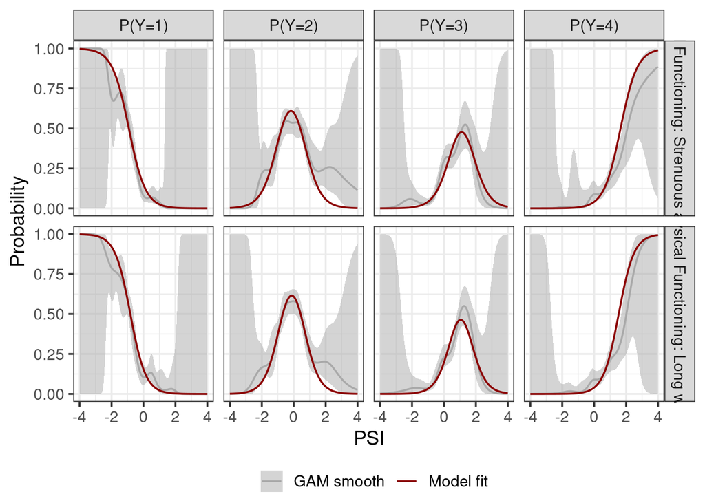

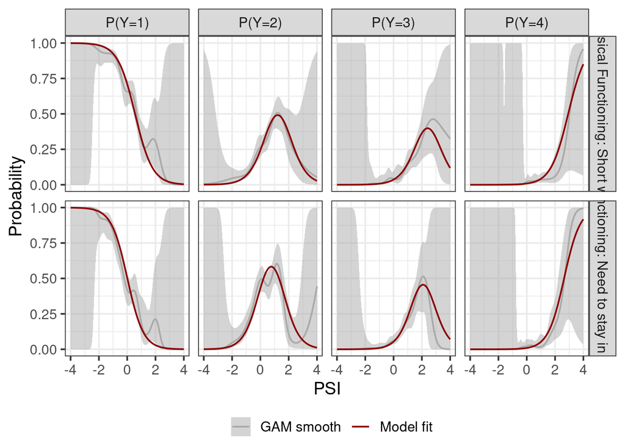

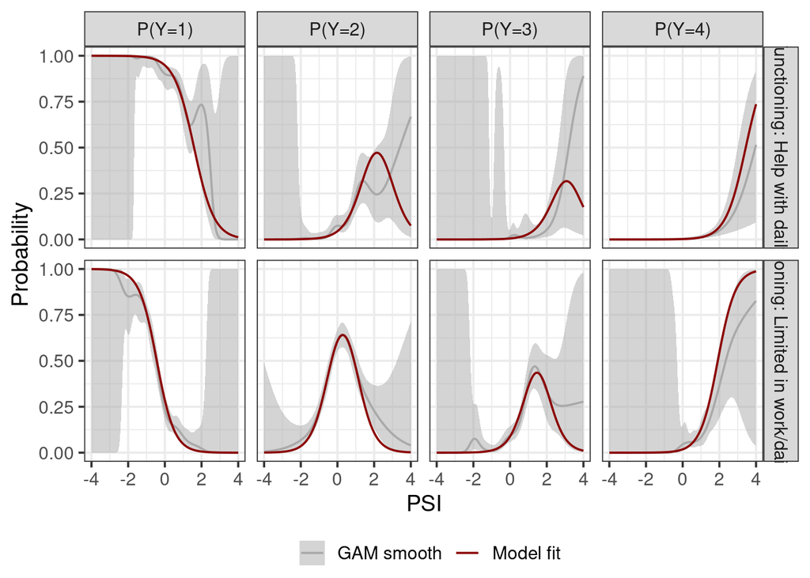

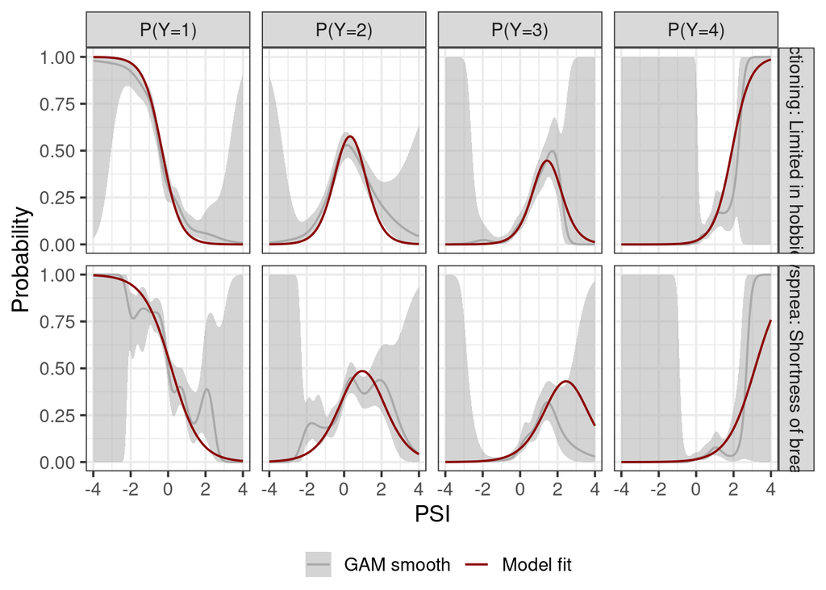

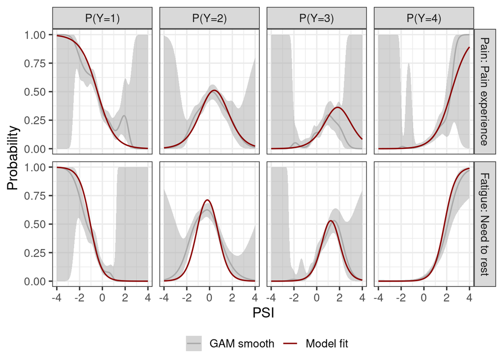

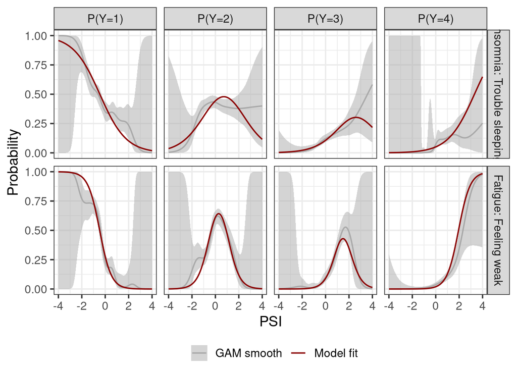

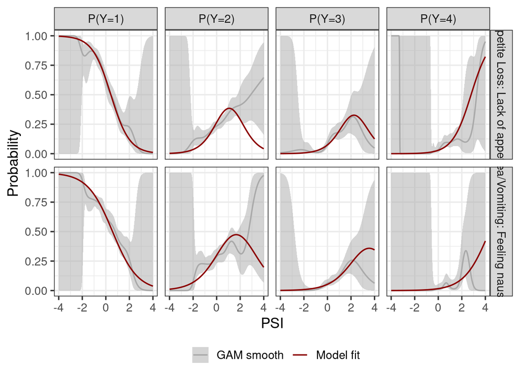

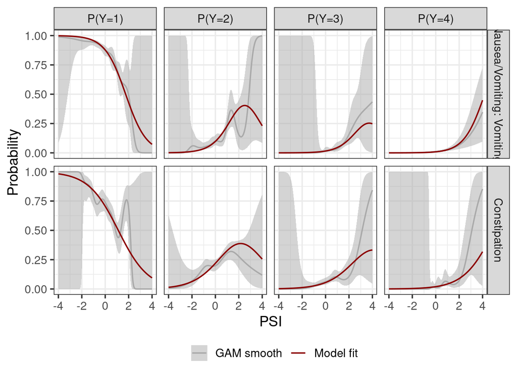

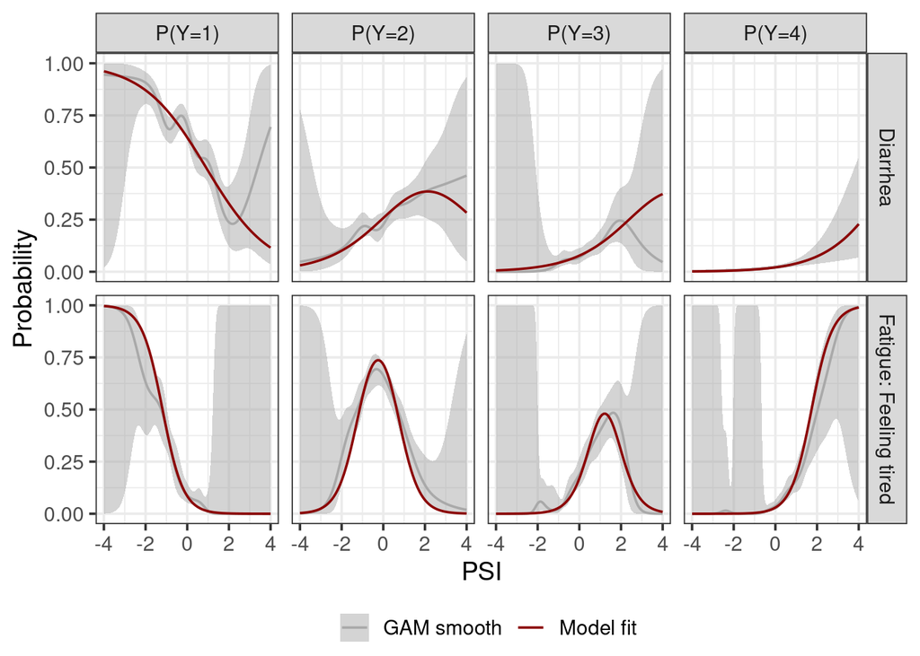

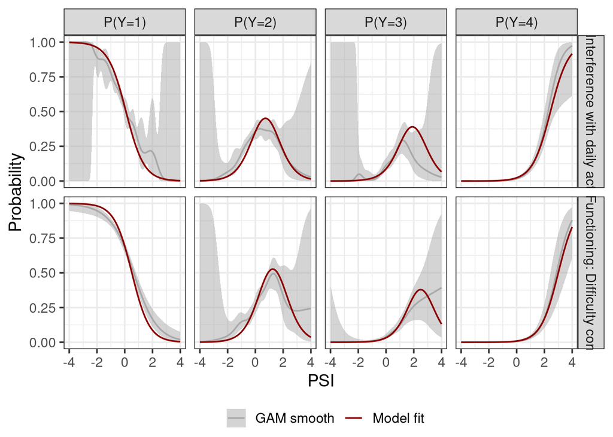

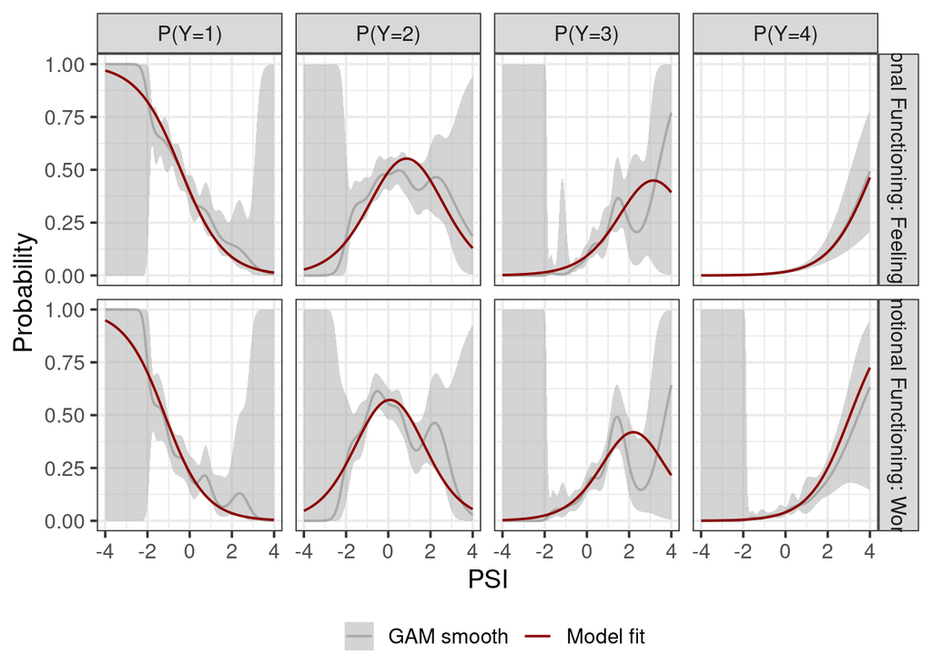

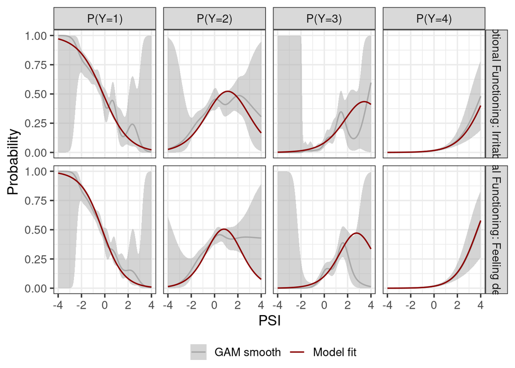

[2 more figures not shown]

```r
df1 <- read.table(file.path(nonmem_dir, "irt_tab2"),
                  skip=1, header=T, sep=c("", ","))
df2 <- read.table(file.path(nonmem_dir, "prob_tab2"),
                  skip=1, header=T, sep=c("", ","))

# Forgot to output covariates in nonmem model so just merging here
df <- full_join(df1, df2) %>%
          full_join(., datnm2)

icc_plots(model, df, items_per_page=2, resample_psi=TRUE, samples=10)
```

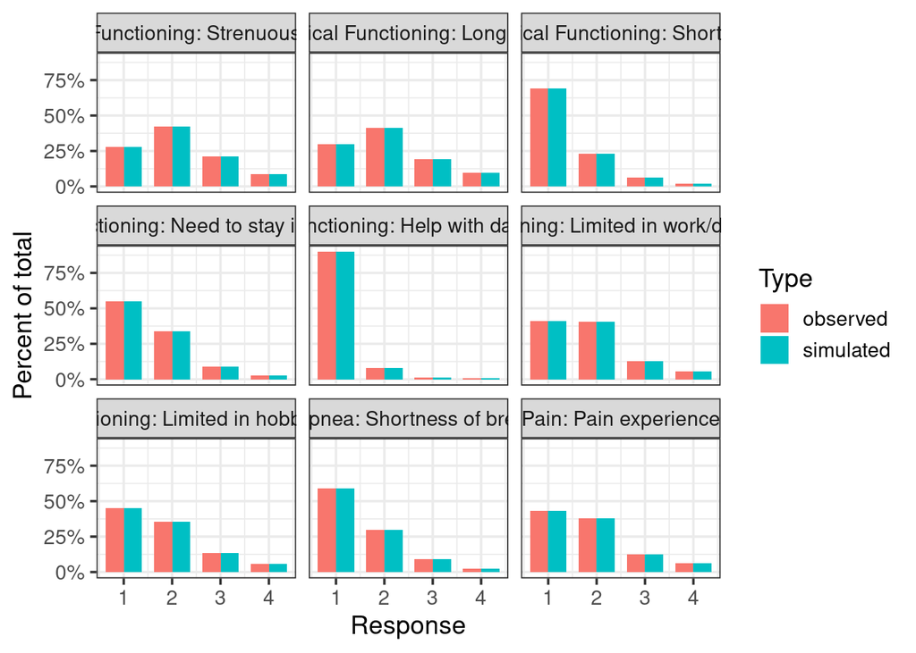

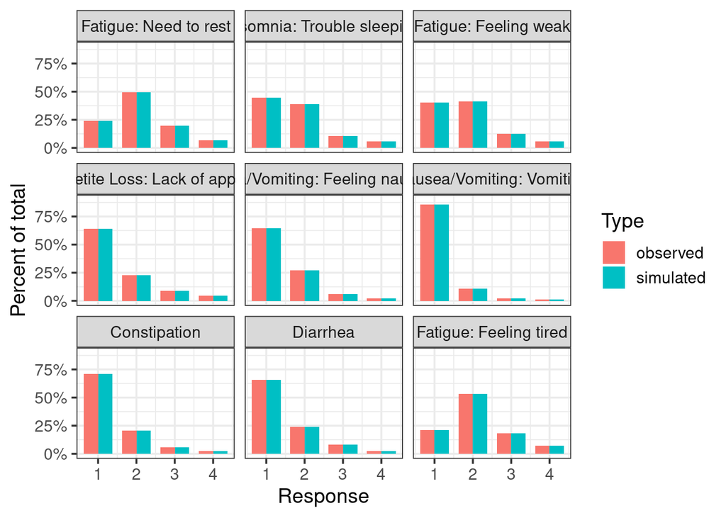

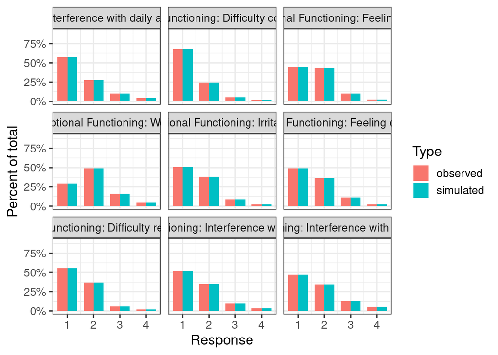

```r
diagnose_marginal_probability(model, simdata=df1, nrow = 3, ncol = 3)
```

## PSI vs. Covariates

Let’s visualize PSI changes over time and as a function of covariates.

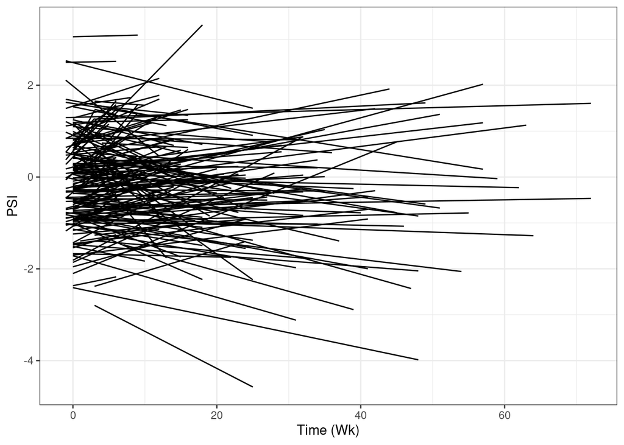

```r
# PSI vs. TIME
P3 <- ggplot(data=df, aes(x=TIME, y=PSI)) +
       geom_line(aes(group=ID)) +
       xlab("Time (Wk)") +
       ylab("PSI") +
       theme_bw()
P3
```

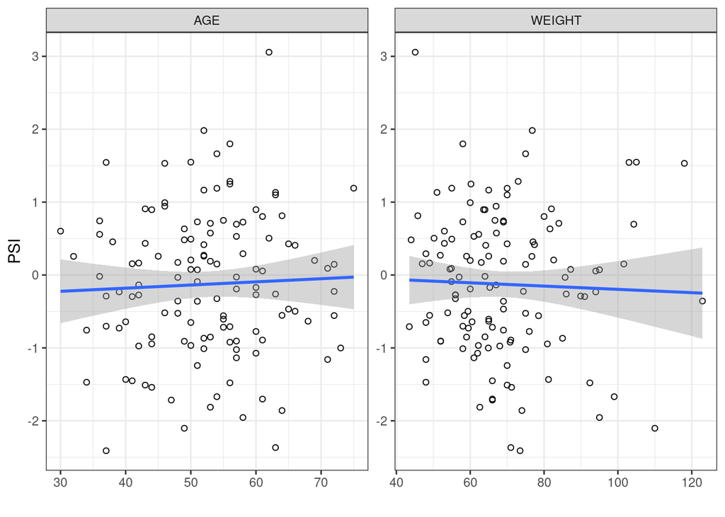

```r
# Baseline PSI vs. continuous covariates
plotdat <- df %>%
  filter(TIME==0, ITEM==1) %>%
  group_by(ID) %>%
  slice(1) %>% ungroup() %>%
  tidyr::gather(c("AGE", "WEIGHT"), key="key", value="value") %>%
  ungroup()

P4 <- ggplot(data=plotdat, aes(x=value, y=PSI)) +
       geom_point(shape=1) +
       xlab("") +
       ylab("PSI") +
       facet_wrap(~key, scales="free") +
       geom_smooth(method="lm") +
       theme_bw()
P4
```

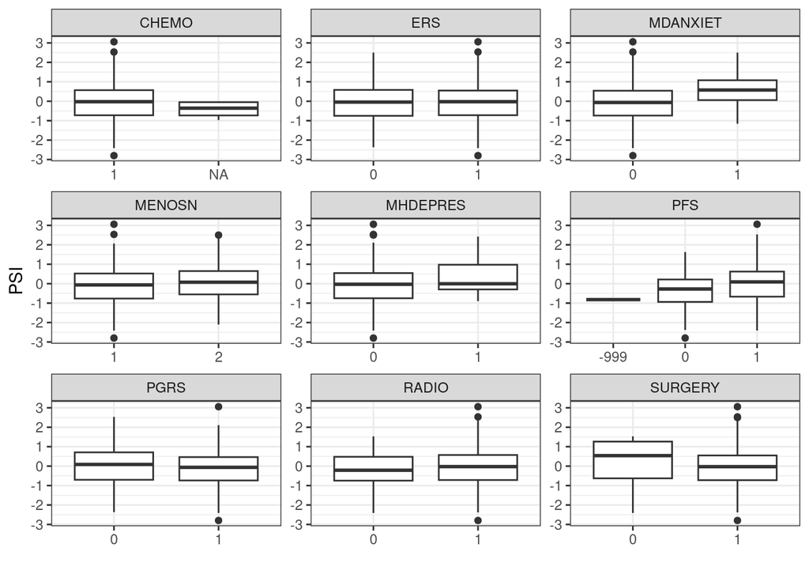

```r
# Baseline PSI vs. categorical covariates
plotdat <- df %>%
  group_by(ID) %>%
  slice(1) %>% ungroup() %>%
  tidyr::gather(c("CHEMO", "SURGERY", "RADIO",
                   "ERS", "PGRS", "MHDEPRES", "MDANXIET",
                   "MENOSN", "PFS"), key="key", value="value") %>%
  ungroup()

P5 <- ggplot(data=plotdat, aes(x=factor(value), y=PSI)) +
       geom_boxplot() +
       xlab("") +
       ylab("PSI") +
       facet_wrap(~key, scales="free") +
       theme_bw()
P5
```

```r
# Check correlations between AGE, WEIGHT, and LESION1
# corr <- round(cor(df %>%
#   filter(TIME==0, ITEM==1) %>%
#   group_by(ID) %>%
#   slice(1) %>%
#   ungroup()%>%
#   select(AGE,WEIGHT)), 2)
# corr
# Only very weak correlations
```

## Add age as a continuous covariate on baseline PSI in run3

update_inits run2.mod run2.lst -output_model=run3.mod

Based on the review of covariate plots, let’s test addition of age as a covarite on baseline PSI (linear model). Lowest age is 30 in the dataset. We will input dataset to Analysis_Data_nm_wCov.csv in run2. Now, we will update run3.mod PSI model manually.

$$BasePSI = THETA(109) + ETA(1)$$
$$BasePSIAGE = BasePSI * (1 +
THETA(111)*(AGE-30))$$
$$TMSLP =
THETA(110) + ETA(2)$$
$$PSI =
BasePSIAGE + TMSLP*TIME$$

Upon running run3, dOFV from run2 = -0.46 ~ not significant. We could evaluate other covariates, too. For the purpose of this tutorial, consider run2 as the final model.

## VPCs

### Total score prediction corrected

Run continuous total score vs. TIME VPC using command –> vpc run2vpc.mod -flip_comments -samples=500 -dir=vpc2.1 -predcorr

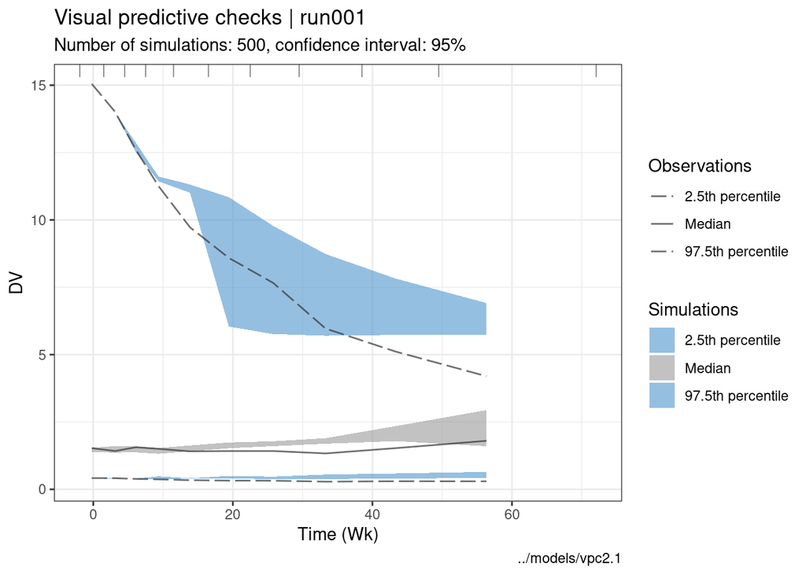

```r
vpcdat <- xpose::vpc_data(xpdb_ex_pk,
                          psn_folder="../models/vpc2.1",
                          psn_bins=T)

P1 <- vpc(vpcdat, smooth =T, type="alr") +
  xlab("Time (Wk)") +
  theme_bw()
P1
```

### Categorical prediction corrected

Run categorical VPC using command –> vpc run2vpc.mod -flip_comments -samples=500 -dir=vpc2.2 -predcorr -levels=0,1,2,3,4

```r
# Categorical
vpcdat <- xpose::vpc_data(xpdb_ex_pk, vpc_type = "categorical",
                          psn_folder="../models/vpc2.2",
                          psn_bins=T)
```

[output not shown]

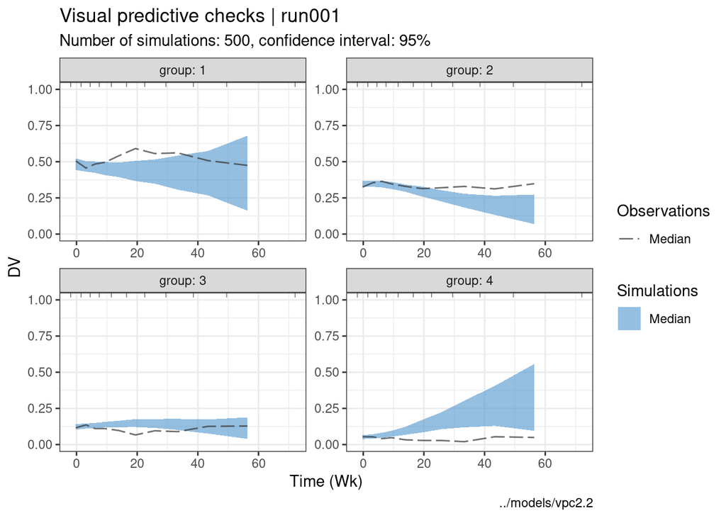

```r
P2 <- vpc(vpcdat, smooth =T, type="alr") +
  xlab("Time (Wk)") +
  theme_bw()
P2
```

### Continuous per item

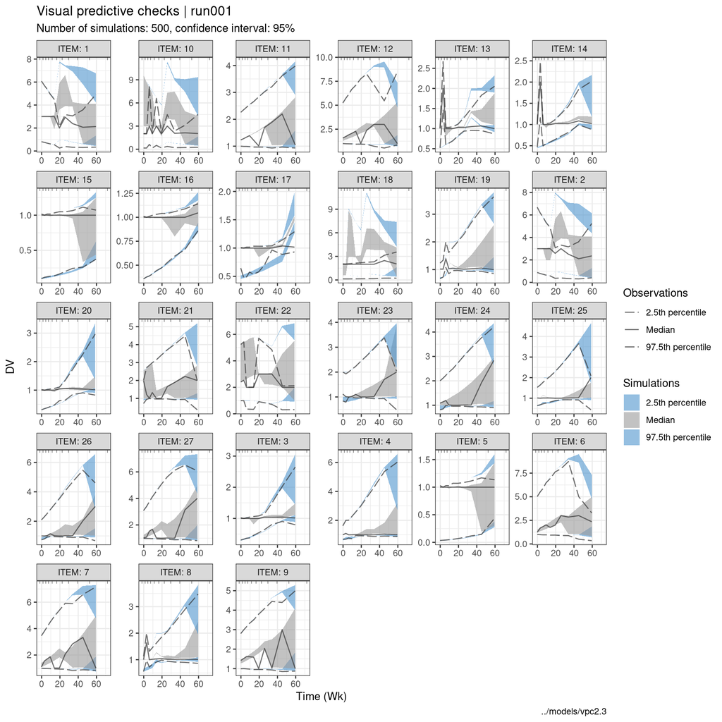

```r
# Categorical
vpcdat <- xpose::vpc_data(xpdb_ex_pk,
                          psn_folder="../models/vpc2.3",
                          psn_bins=T)

P3 <- vpc(vpcdat, smooth =T, type="alr", ) +
  xlab("Time (Wk)") +
  theme_bw()
P3
```

Note that the model fits are not the greatest. For the purpose of this tutorial, we showcase simple linear additive time effect model. Note that we do not model treatment effects here as the data is from control arm only. Ideally, other model structures and evaluations of covariate effects can be performed to improve model fits.